# R Notebook

# Lab assignment 4

## Team

*Vladyslav Vasylchenko, Max Holovin, Ostap Kostiuk*

## Work distribution

Vlad - 1, 2  
Max - 3  
Ostap - 4

# Problem 1

In this problem we have two independent samples $X_1,\dots,X_{100}$ and $Y_1,\dots,Y_{50}$, which we model as observations from normal distributions $X_i \sim N(\mu_1, 1)$ and $Y_j \sim N(\mu_2, 1)$.

We test the hypotheses $H_0: \mu_1 = \mu_2 \quad \text{vs} \quad H_1: \mu_1 \neq \mu_2$ under known variances $\sigma_1^2 = \sigma_2^2 = 1$.

The sequence $a_k$ is defined as
$$a_k = \{ k \ln(k^2 n + \pi) \}, \quad k \ge 1,$$
where the fractional part of a number $x$ is defined as
$$\{x\} = x - \lfloor x \rfloor .$$

The data are then generated as
$$x_k = \Phi^{-1}(a_k), \quad k = 1,\dots,100,$$
$$y_l = \Phi^{-1}(a_{l+100}), \quad l = 1,\dots,50,$$
where $\Phi^{-1}$ is the quantile function of the standard normal distribution (the `qnorm` function in R).

Since the variances are known, the standard procedure is the two-sample Z-test for the difference of means.

```r
team_id <- 10

a_fun <- function(k, n) {
  x <- k * log(k^2 * n + pi)
  x - floor(x)
}

k_max  <- 150
a_data <- sapply(1:k_max, a_fun, n = team_id)

range(a_data)
```

```
[1] 0.003319811 0.989452036
```

```r
x <- qnorm(a_data[1:100])

y <- qnorm(a_data[101:150])

length(x); length(y)
```

```
[1] 100
```

```
[1] 50
```

We denote the sample means as
$$\bar X = \frac{1}{n_1}\sum_{i=1}^{n_1} X_i,
\qquad
\bar Y = \frac{1}{n_2}\sum_{j=1}^{n_2} Y_j,$$
where $n_1 = 100$ and $n_2 = 50$.

According to the problem assumptions,
$$X_i \sim N(\mu_1, 1), \qquad Y_j \sim N(\mu_2, 1),$$
therefore
$$\bar X \sim N\!\left(\mu_1,\; \frac{1}{n_1}\right),
\qquad
\bar Y \sim N\!\left(\mu_2,\; \frac{1}{n_2}\right).$$

Then the difference of the sample means has the distribution
$$\bar X - \bar Y \sim
N\!\left(\mu_1 - \mu_2,\; \frac{1}{n_1} + \frac{1}{n_2}\right).$$

Under the null hypothesis $H_0:\mu_1 = \mu_2$ we have
$$\bar X - \bar Y \sim
N\!\left(0,\; \frac{1}{n_1} + \frac{1}{n_2}\right).$$

Hence, the test statistic
$$Z = \frac{\bar X - \bar Y}
{\sqrt{\frac{1}{n_1} + \frac{1}{n_2}}}$$
has the standard normal distribution $N(0,1)$ when $H_0$ is true.

```r
n1 <- length(x)
n2 <- length(y)

x_bar <- mean(x)
y_bar <- mean(y)

n1; n2
```

```
[1] 100
```

```
[1] 50
```

```r
x_bar; y_bar
```

```
[1] -0.06705019
```

```
[1] 9.986778e-05
```

```r
sigma1_sq <- 1
sigma2_sq <- 1

se_diff <- sqrt(sigma1_sq / n1 + sigma2_sq / n2)

z_obs <- (x_bar - y_bar) / se_diff
z_obs
```

```
[1] -0.387691
```

We use a two-sided test because the alternative hypothesis is $H_1:\mu_1 \neq \mu_2$.

The significance level is $\alpha = 0.05$.

For the standard normal distribution the critical points are $z_{1-\alpha/2} = z_{0.975}$. The critical region is
$$\mathrm{Cr} = \{ z : |z| > z_{1-\alpha/2} \}.$$

```r
alpha  <- 0.05
z_crit <- qnorm(1 - alpha/2)
z_crit
```

```
[1] 1.959964
```

```r
abs(z_obs) > z_crit
```

```
[1] FALSE
```

If $\lvert Z_{\text{obs}}\rvert > z_{1-\alpha/2}$, we reject $H_0$.

For the two-sided Z-test the p-value is computed as
$$p\text{-value}
= 2\bigl(1 - \Phi(\lvert Z_{\text{obs}}\rvert)\bigr),$$
where $\Phi$ is the cumulative distribution function of the standard normal distribution.

```r
p_value <- 2 * (1 - pnorm(abs(z_obs)))
p_value
```

```
[1] 0.6982447
```

Interpretation:

- If $p\text{-value} < 0.05$, we reject $H_0$ at the significance level $\alpha = 0.05$ and conclude that $\mu_1$ and $\mu_2$ are statistically different.
- If $p\text{-value} \ge 0.05$, we do not reject $H_0$: the observed data do not provide sufficient evidence to claim that the population means are different.

# Problem 2

In this part we test hypotheses about the variances of two normal populations:

$$H_0: \sigma_1^2 = \sigma_2^2
\quad \text{vs} \quad
H_1: \sigma_1^2 > \sigma_2^2,$$

where $X_1,\dots,X_{n_1}$ and $Y_1,\dots,Y_{n_2}$ are the same samples as in Problem 1, with $n_1 = 100$, $n_2 = 50$, and the means $\mu_1$, $\mu_2$ are assumed to be unknown.

We assume that
$$X_i \sim N(\mu_1, \sigma_1^2), \qquad Y_j \sim N(\mu_2, \sigma_2^2),$$
and that the samples are independent. The standard test for comparing two variances of normal distributions is the **F-test**.

The sample variances are defined as
$$S_1^2 = \frac{1}{n_1-1} \sum_{i=1}^{n_1} (X_i - \bar X)^2, \qquad
S_2^2 = \frac{1}{n_2-1} \sum_{j=1}^{n_2} (Y_j - \bar Y)^2.$$

For normal data we know that
$$\frac{(n_1-1)S_1^2}{\sigma_1^2} \sim \chi^2_{n_1-1},
\qquad
\frac{(n_2-1)S_2^2}{\sigma_2^2} \sim \chi^2_{n_2-1},$$
and these two chi-squared variables are independent.

Under the null hypothesis $H_0:\sigma_1^2 = \sigma_2^2$ the test statistic
$$F = \frac{S_1^2}{S_2^2}$$
has the F-distribution with $(n_1-1, n_2-1)$ degrees of freedom:
$$F \sim F_{n_1-1,,n_2-1}.$$

Since the alternative hypothesis is one-sided ($\sigma_1^2 > \sigma_2^2$), the critical region for significance level $\alpha = 0.05$ is
$$\mathrm{Cr} = { f : f > F_{1-\alpha}(n_1-1, n_2-1) },$$
where $F_{1-\alpha}(n_1-1, n_2-1)$ is the $(1-\alpha)$-quantile of the $F_{n_1-1,,n_2-1}$ distribution.

```r
s1_sq <- var(x)
s2_sq <- var(y)

s1_sq
```

```
[1] 0.8013433
```

```r
s2_sq
```

```
[1] 1.216986
```

```r
F_obs <- s1_sq / s2_sq
F_obs
```

```
[1] 0.6584653
```

```r
alpha <- 0.05

F_crit <- qf(1 - alpha, df1 = n1 - 1, df2 = n2 - 1)
F_crit
```

```
[1] 1.530999
```

```r
F_obs > F_crit
```

```
[1] FALSE
```

If $F_obs \> F_crit$, we reject $H_0$ at the significance level $\alpha = 0.05$. Otherwise, we do not reject $H_0$.

For the one-sided test $H_1:\sigma_1^2 > \sigma_2^2$ the p-value is
$$p\text{-value}
= P\bigl(F_{n_1-1,,n_2-1} \ge F_{\text{obs}}\bigr)
= 1 - F_F(F_{\text{obs}}),$$
where $F_F$ is the cumulative distribution function of the F-distribution.

```r
p_value_F <- 1 - pf(F_obs, df1 = n1 - 1, df2 = n2 - 1)
p_value_F
```

```
[1] 0.9597745
```

Interpretation:

• If $p\text{-value} < 0.05$, we reject $H_0$ at the significance level $\alpha = 0.05$ and conclude that the variance of the first population is significantly larger than the variance of the second population.

• If $p\text{-value} \ge 0.05$, we do not reject $H_0$. In this case, the observed data do not provide sufficient evidence to claim that $\sigma_1^2 > \sigma_2^2$.

## Task 3

The problem asks to check distribution properties of the generated samples using the Kolmogorov–Smirnov (KS) test.

The Kolmogorov–Smirnov test is a non-parametric test used to determine if a sample comes from a specific distribution (one-sample KS test) or if two samples come from the same distribution (two-sample KS test).
The test is based on the Empirical Cumulative Distribution Function.
One-Sample: The KS test statistic, $D$, measures the maximum absolute difference between the ECDF of the sample, $F_n(t)$, and the hypothesized theoretical Cumulative Distribution Function (CDF), $F(t)$.
$$D =
\sup_t |F_n(t) - F(t)|$$
Two-Sample: The KS test statistic, $D$, measures the maximum absolute difference between the ECDFs of the two samples, $F_{n_1}(t)$ and $F_{n_2}(t)$.
$$D
= \sup_t |F_{n_1}(t) - F_{n_2}(t)|$$
A large value of $D$ suggests a poor fit or different underlying distributions. The test rejects the null hypothesis ($H_0$) if the $D$ statistic exceeds a critical value $C$ (based on the sample size(s) and significance level $\alpha$), or, equivalently, if the $p$-value is less than $\alpha$.
The function $a_k = \{k \ln (k^{2n} + \pi)\}$ generates a sequence in $(0, 1)$ that approximates a uniform $U(0, 1)$ distribution. Applying $\Phi^{-1}$ (the qnorm function) transforms this uniform sequence into a sequence that approximates a standard normal $N(0, 1)$ distribution.

For a significance level $\alpha=0.05$, the rejection rule is:
$$\text{Reject } H_0 \text{ if } D > C, \quad
\text{or, equivalently, if } p\text{-value} < 0.05$$
Where $D$ is the KS test statistic (the maximum absolute difference between the ECDFs) and $C$ is the critical value for the specified $\alpha$.

```r
n <- 10
set.seed(n)
k_values <- 1:150

a_k_full <- (k_values * log(k_values^(2*n) + pi)) %% 1

a_x <- a_k_full[1:100]
a_y <- a_k_full[101:150]

x <- qnorm(a_x)
y <- qnorm(a_y)
```

a)  
Task: Check if $\{x_k\}_{k=1}^{100}$ are normally distributed (with parameters calculated from the sample).  
I used Kolmogorov–Smirnov test to compare an empirical distribution function (EDF) against a specified theoretical distribution function (CDF).  
Hypotheses  
$H_0$: $\{x_k\}$ follows a Normal distribution $N(\mu, \sigma^2)$ where $\mu$ and $\sigma$ are the sample mean and standard deviation.  
$H_1$: $\{x_k\}$ does not follow this Normal distribution.

```r
sample_mean_x <- mean(x)
sample_sd_x <- sd(x)
cat("Sample Mean of x:", sample_mean_x, "\n")
```

```
Sample Mean of x: -0.2437349
```

```r
cat("Sample SD of x:", sample_sd_x, "\n")
```

```
Sample SD of x: 1.02439
```

```r
ks_test_a <- ks.test(x, "pnorm", mean = sample_mean_x, sd = sample_sd_x)
print(ks_test_a)
```

```
    Asymptotic one-sample Kolmogorov-Smirnov test

data:  x
D = 0.061756, p-value = 0.8402
alternative hypothesis: two-sided
```

Since our p-value(0.8402) is > 0.05, we can’t reject $H_0$  
The generated $x_k$ values are derived directly from the standard normal CDF inverse ($\Phi^{-1}$) applied to a $U(0, 1)$ sequence. Thus, the data is by construction an excellent approximation of a standard normal distribution. The high $p$-value confirms that the observed deviations from the normal CDF are well within the range expected by chance if $H_0$ were true.

2. Task: Check if $\{|x_k|\}_{k=1}^{100}$ are exponentially distributed with $\lambda = 1$.  
   I used Kolmogorov–Smirnov test to compare the EDF of the sample $\mathbf{|x|}$ against the fixed theoretical $\text{Exp}(\lambda=1)$ CDF.  
   $H_0$: $\{|x_k|\}$ follows an $\text{Exp}(\lambda=1)$ distribution (mean $= 1$).  
   $H_1$: $\{|x_k|\}$ does not follow this Exponential distribution.

```r
abs_x <- abs(x)
sample_mean_abs_x <- mean(abs_x)
cat("Sample Mean of |x|:", sample_mean_abs_x, "\n")
```

```
Sample Mean of |x|: 0.8137065
```

```r
ks_test_b <- ks.test(abs_x, "pexp", rate = 1)
print(ks_test_b)
```

```
    Asymptotic one-sample Kolmogorov-Smirnov test

data:  abs_x
D = 0.10445, p-value = 0.2253
alternative hypothesis: two-sided
```

3. Task: Check if $\{x_k\}_{k=1}^{100}$ and $\{y_l\}_{l=1}^{50}$ have the same distributions.  
   I used Kolmogorov–Smirnov test to compare the EDFs of two independent samples ($\mathbf{x}$ and $\mathbf{y}$) to determine if they originate from the same underlying continuous distribution.  
   $H_0$: $\{x_k\}$ and $\{y_l\}$ are drawn from the same continuous distribution.  
   $H_1$: $\{x_k\}$ and $\{y_l\}$ are drawn from different continuous distributions.

```r
sample_mean_y <- mean(y)
sample_sd_y <- sd(y)
cat("Sample Mean of x:", sample_mean_x, "\n")
```

```
Sample Mean of x: -0.2437349
```

```r
cat("Sample Mean of y:", sample_mean_y, "\n")
```

```
Sample Mean of y: 0.03727885
```

```r
cat("Sample SD of x:", sample_sd_x, "\n")
```

```
Sample SD of x: 1.02439
```

```r
cat("Sample SD of y:", sample_sd_y, "\n")
```

```
Sample SD of y: 0.9012762
```

```r
ks_test_c <- ks.test(x, y)
print(ks_test_c)
```

```
    Exact two-sample Kolmogorov-Smirnov test

data:  x and y
D = 0.17, p-value = 0.2811
alternative hypothesis: two-sided
```

# Task 4

## Problem statement

In this task you’ll practice fitting the regression line to some real-life features and analyzing the results. The file data.csv contains data on students, specifically their study time and corresponding marks. Your tasks are as follows: (a) Create a scatter plot of Marks vs. Study Time and provide brief comments;  
(b) Fit a linear regression model using marks as the dependent variable and study time as the independent variable. Explain shortly the process of deriving the regression equation;  
(c) Evaluate the goodness-of-fit for the fitted line;  
(d) Suggest a way to test whether the study time is significant in predicting marks. Find the corresponding test statistics, specify its distribution. Find the p-value of the test and make a conclusion;  
(e) If Alice studies for approximately 8 hours, what grade can we predict for her?  
(f) Suggest up to three ideas to potentially improve prediction accuracy;

## Solution

**Importing data**

```r
data <- read.csv("data.csv")
head(data)
```

|  | time_study | Marks |
| --- | --- | --- |
| 1 | 4.508 | 19.202 |
| 2 | 0.096 | 7.734 |
| 3 | 3.133 | 13.811 |
| 4 | 7.909 | 53.018 |
| 5 | 7.811 | 55.299 |
| 6 | 3.211 | 17.822 |

```r
str(data)
```

```
'data.frame':   100 obs. of  2 variables:
 $ time_study: num  4.508 0.096 3.133 7.909 7.811 ...
 $ Marks     : num  19.2 7.73 13.81 53.02 55.3 ...
```

```r
summary(data)
```

```
   time_study        Marks
 Min.   :0.096   Min.   : 5.609
 1st Qu.:2.058   1st Qu.:12.633
 Median :4.022   Median :20.059
 Mean   :4.077   Mean   :24.418
 3rd Qu.:6.179   3rd Qu.:36.676
 Max.   :7.957   Max.   :55.299
```

**(a)**

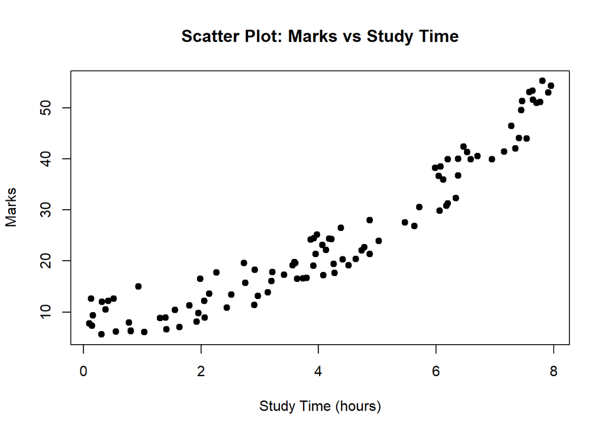

```r
plot(data$time_study, data$Marks,
     xlab = "Study Time (hours)",
     ylab = "Marks",
     main = "Scatter Plot: Marks vs Study Time",
     pch = 19)
```

*Comments*: The trend is obvious - with the rise of study time, values of marks also increase. An approximately linear relationship is observed, which allows the application of linear regression

**(b)**

```r
model <- lm(Marks ~ time_study, data = data)
summary(model)
```

```
Call:
lm(formula = Marks ~ time_study, data = data)

Residuals:
   Min     1Q Median     3Q    Max
-7.866 -4.034 -0.384  2.979 10.628

Coefficients:
            Estimate Std. Error t value Pr(>|t|)
(Intercept)   1.2239     0.9623   1.272    0.206
time_study    5.6888     0.2042  27.853   <2e-16 ***
---
Signif. codes:  0 '***' 0.001 '**' 0.01 '*' 0.05 '.' 0.1 ' ' 1

Residual standard error: 4.822 on 98 degrees of freedom
Multiple R-squared:  0.8878,    Adjusted R-squared:  0.8867
F-statistic: 775.8 on 1 and 98 DF,  p-value: < 2.2e-16
```

```r
coef(model)
```

```
(Intercept)  time_study
   1.223858    5.688750
```

Visualization:

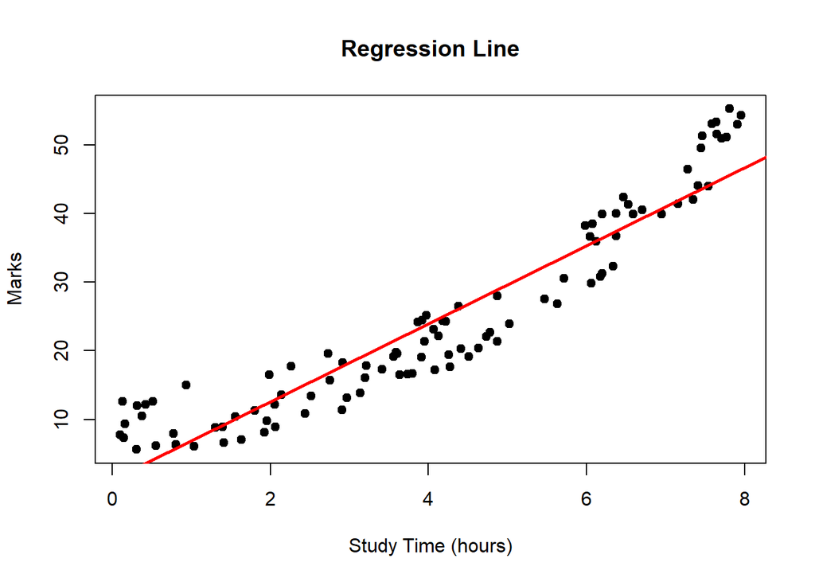

```r
plot(data$time_study, data$Marks,
     xlab = "Study Time (hours)",
     ylab = "Marks",
     pch = 19,
     main = "Regression Line")

abline(model, col = "red", lwd = 2.5)
```

To find the regression equation, we look for a straight line that best describes the relationship between study time (X) and marks (Y). The line has the form:  
Y = a + bx,  
where a is an intercept and b is a slope.  
We get these values by using *least squares method*.

**(c)**

The model fits the data very well.  
The R-squared is 0.8878, which means that about 88.8% of the variation in marks is explained by study time.  
The Residual Standard Error (RSE) is 4.82, meaning that, on average, the predictions differ from the actual marks by about 4–5 points.  
For real-life data, this is reasonably accurate.  
The F-statistic is 775.8 with a p-value below 2e-16, which shows that the overall regression model is highly significant.  
In other words, the linear relationship is not due to some random chance.  
Overall, the regression line provides a very good fit to the data.

**(d)**

We test whether the slope (the coefficient of `time_study`) is equal to zero.

This is a **t-test** on the slope coefficient.

So the test statistic is:

t = estimate / SE

From summary we saw earlier we already know these values, so let’s plug them in.

t = 27.853.

As R shows - the p-value is extremely small - practically zero.

Since the p-value is far below 0.05, we **reject H₀**.

Study time **is highly significant** in predicting marks.

**(e)** Using the regression equation Y = a + bx, we can plug in x = 8.  
Y = 46.733858.

We can also do the same using R function:

```r
predict(model, newdata = data.frame(time_study = 8))
```

```
       1
46.73386
```

**(f)**

First thing we can do is to use more predictors (if we had them), such as for example *hours of sleep*, or *course difficulty*.  
Also, as we can see from the plot earlier our data has slight curvature, so allowing non-linear relationship should be a good idea.